# **Day 11**

**Naive Bayes Classifier**

It is a kind of classifier that works on Bayes theorem. Prediction of membership probabilities is made for every class such as the probability of data points is associated a particular class.

**Problem Statement**

To classify patients as diabetic or non-diabetic. The dataset has several different medical predictor features and a target that is **Outcome**. Predictor variables include the number of pregnancies that patient had, their BMI, insulin level, age and so on.....

```python
#import libraries
import numpy as np
import pandas as pd

import seaborn as sns
sns.set(color_codes=True)
import matplotlib.pyplot as plt
%matplotlib inline

#sklearn libraries
from sklearn.model_selection import train_test_split
from sklearn.naive_bayes import GaussianNB
from sklearn.preprocessing import StandardScaler
from sklearn import metrics
```

```python
#lets define col names
colnames = ['preg','plas','pres','skin','test','mass','pedi','age','class']
pimadf = pd.read_csv("/content/pima-indians-diabetes.data", names=colnames)
```

```python
pimadf.head()
```

|  | preg | plas | pres | skin | test | mass | pedi | age | class |
| --- | --- | --- | --- | --- | --- | --- | --- | --- | --- |
| 0 | 6 | 148 | 72 | 35 | 0 | 33.6 | 0.627 | 50 | 1 |
| 1 | 1 | 85 | 66 | 29 | 0 | 26.6 | 0.351 | 31 | 0 |
| 2 | 8 | 183 | 64 | 0 | 0 | 23.3 | 0.672 | 32 | 1 |
| 3 | 1 | 89 | 66 | 23 | 94 | 28.1 | 0.167 | 21 | 0 |
| 4 | 0 | 137 | 40 | 35 | 168 | 43.1 | 2.288 | 33 | 1 |

```python
std = StandardScaler()
```

```python
X = pimadf.drop("class", axis=1)
Y = pimadf['class']
```

```python
X = std.fit_transform(X)
```

```python
#Lets split the data
X_train, X_test, Y_train, Y_test = train_test_split(X,Y, test_size = 0.30, random_state=7)
```

```python
#lets choose the model
model = GaussianNB()
```

```python
#Lets train the model
model.fit(X_train, Y_train)
print(model)
```

```
GaussianNB(priors=None, var_smoothing=1e-09)
```

```python
#lets make the predictions
pred = model.predict(X_test)
```

```python
#lets check the accuracy of the model by printing its score
from sklearn.metrics import accuracy_score, confusion_matrix

model_score = model.score(X_test, Y_test)
model_score
```

```
0.7402597402597403
```

```python
metrics.confusion_matrix(pred, Y_test)
```

```
array([[116,  29],
       [ 31,  55]])
```

```python
#lets find the probability
y_pred_prob = model.predict_proba(X_test)
```

```python
from sklearn.metrics import auc, roc_curve

fpr,tpr,thresholds = roc_curve(Y_test, y_pred_prob[::,1])
roc_auc = auc(fpr,tpr)
roc_auc
```

```
0.7973760932944606
```

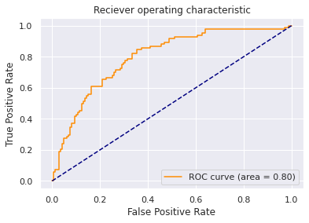

```python
#lets plot the roc curve
plt.plot(fpr,tpr, color='darkorange', label='ROC curve (area = %0.2f)' % roc_auc)
plt.plot([0,1],[0,1], color='navy', linestyle='--')
plt.xlabel('False Positive Rate')
plt.ylabel('True Positive Rate')
plt.title('Reciever operating characteristic')
plt.legend(loc='lower right')
plt.show()
```

**KMeans Clustering**

Division of datapoints into clusters such that each data point is present in only one cluster

**Problem Statement**

To analyze the type of customers in the market based on the features

```python
#lets import the libraries
import numpy as np
import pandas as pd
import matplotlib.pyplot as plt
import seaborn as sns
sns.set()
```

```python
#load the data into data variable
data = pd.read_csv('/content/Example.csv')
data.head()
```

|  | Satisfaction | Loyalty |
| --- | --- | --- |
| 0 | 4 | -1.33 |
| 1 | 6 | -0.28 |
| 2 | 5 | -0.99 |
| 3 | 7 | -0.29 |
| 4 | 4 | 1.06 |

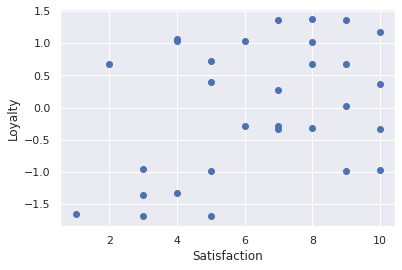

```python
#plot the data using scatter plot: hint: x=data[Satisfaction], y=data['Loyalty]
plt.scatter(data['Satisfaction'], data['Loyalty'])
plt.xlabel('Satisfaction')
plt.ylabel('Loyalty')
plt.show()
```

```python
#copy the entire data into X and select the features
X = data.copy()
```

```python
#Clustering
from sklearn.cluster import KMeans

kmeans = KMeans(2)
kmeans.fit(X)
```

```
KMeans(algorithm='auto', copy_x=True, init='k-means++', max_iter=300,
       n_clusters=2, n_init=10, n_jobs=None, precompute_distances='auto',
       random_state=None, tol=0.0001, verbose=0)
```

```python
#Lets copy the clustering result
clusters = X.copy()
clusters['cluster_pred'] = kmeans.fit_predict(X)
```

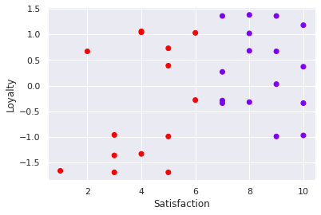

```python
#lets plot the clustered data
plt.scatter(clusters['Satisfaction'],clusters['Loyalty'], c = clusters['cluster_pred'], cmap='rainbow')
plt.xlabel('Satisfaction')
plt.ylabel('Loyalty')
plt.show()
```

```python
#lets standardize the variables
from sklearn import preprocessing

x_scaled = preprocessing.scale(X)
x_scaled
```

```
array([[-0.93138063, -1.3318111 ],
       [-0.15523011, -0.28117124],
       [-0.54330537, -0.99160391],
       [ 0.23284516, -0.29117733],
       [-0.93138063,  1.05964534],
       [-2.09560642, -1.6620122 ],
       [ 1.39707095, -0.97159172],
       [ 0.62092042, -0.32119561],
       [ 0.62092042,  1.01962097],
       [ 0.62092042,  0.67941378],
       [ 1.39707095, -0.3412078 ],
       [-0.54330537,  0.38923705],
       [-0.54330537, -1.69203048],
       [-1.70753116,  0.66940768],
       [ 0.23284516,  0.26916393],
       [ 1.00899568,  1.35982816],
       [ 0.62092042,  1.37984035],
       [ 0.23284516,  1.35982816],
       [ 0.23284516, -0.3412078 ],
       [ 1.00899568,  0.66940768],
       [ 1.39707095,  1.17971847],
       [-1.31945589, -1.69203048],
       [-0.93138063,  1.03963316],
       [-1.31945589, -0.96158562],
       [-0.15523011,  1.02962706],
       [ 1.00899568, -0.99160391],
       [ 1.39707095,  0.36922486],
       [ 1.00899568,  0.02901767],
       [-1.31945589, -1.36182938],
       [-0.54330537,  0.72944425]])
```

```python
#Elbow method
wcss = []

for i in range(1,30):
  kmeans = KMeans(i)
  kmeans.fit(x_scaled)
  wcss.append(kmeans.inertia_)

wcss
```

```
[60.0,
 29.818973034723147,
 17.913349527387965,
 10.247181805928422,
 7.792695153937187,
 6.569489487091783,
 5.417308168183205,
 4.337110750237059,
 3.8231980448085188,
 3.292886890946914,
 3.0275165821627654,
 2.4009836471184305,
 2.200091880152491,
 1.8855393034053005,
 1.567174687777079,
 1.3083879050713378,
 1.1350097534695136,
 1.0175993461344655,
 0.8384919457944024,
 0.6366791702988839,
 0.5451582152303865,
 0.4451666211152162,
 0.3227119817275011,
 0.24721053307798668,
 0.17170908442847233,
 0.11383861748989679,
 0.0559681505513213,
 0.0014517677692203244,
 0.00020024383023728806]
```

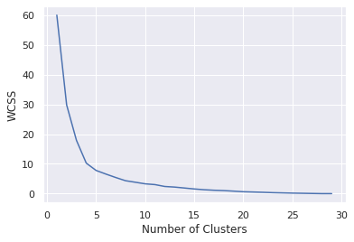

```python
#lets visualize the elbow method
plt.plot(range(1,30), wcss)
plt.xlabel('Number of Clusters')
plt.ylabel('WCSS')
plt.show()
```

```python
#now lets take clusters = 4
kmeans_new = KMeans(4)
kmeans_new.fit(x_scaled)

cluster_new = X.copy()
cluster_new['cluster_pred'] = kmeans_new.fit_predict(x_scaled)
cluster_new
```

|  | Satisfaction | Loyalty | cluster_pred |
| --- | --- | --- | --- |
| 0 | 4 | -1.33 | 1 |
| 1 | 6 | -0.28 | 2 |
| 2 | 5 | -0.99 | 1 |
| 3 | 7 | -0.29 | 2 |
| 4 | 4 | 1.06 | 0 |
| 5 | 1 | -1.66 | 1 |
| 6 | 10 | -0.97 | 2 |
| 7 | 8 | -0.32 | 2 |
| 8 | 8 | 1.02 | 3 |
| 9 | 8 | 0.68 | 3 |
| 10 | 10 | -0.34 | 2 |
| 11 | 5 | 0.39 | 0 |
| 12 | 5 | -1.69 | 1 |
| 13 | 2 | 0.67 | 0 |
| 14 | 7 | 0.27 | 2 |
| 15 | 9 | 1.36 | 3 |
| 16 | 8 | 1.38 | 3 |
| 17 | 7 | 1.36 | 3 |
| 18 | 7 | -0.34 | 2 |
| 19 | 9 | 0.67 | 3 |
| 20 | 10 | 1.18 | 3 |
| 21 | 3 | -1.69 | 1 |
| 22 | 4 | 1.04 | 0 |
| 23 | 3 | -0.96 | 1 |
| 24 | 6 | 1.03 | 0 |
| 25 | 9 | -0.99 | 2 |
| 26 | 10 | 0.37 | 3 |
| 27 | 9 | 0.03 | 2 |
| 28 | 3 | -1.36 | 1 |
| 29 | 5 | 0.73 | 0 |

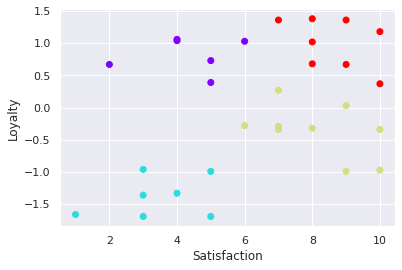

```python
plt.scatter(cluster_new['Satisfaction'],cluster_new['Loyalty'], c = cluster_new['cluster_pred'], cmap='rainbow')
plt.xlabel('Satisfaction')
plt.ylabel('Loyalty')
plt.show()
```